# Course Project Report

Huang Zhe

I build and test the classification model in several steps.

1. **Data Cleanup**

In the training data, I remove all the columns that contain missing values, since they miss such a large proportion of values that the remaining values are hardly useful. I also remove columns about timing, because the 20 testing cases in “pml-testing.csv” do not have timing information. Columns related to user identity are also removed.

```r
library(caret)
library(MASS)
set.seed(12345)
dataset = read.csv("pml-training.csv",na.strings=c(" ","#DIV/0!","NA"));

# remove the columns that have missing data
maskremove = apply(dataset,2,function(x)any(is.na(x)));
maskremove = as.vector(maskremove);

# remove the columns related to time and user identity
maskremove = maskremove | is.element(names(dataset),c("X","user_name","raw_timestamp_part_1","raw_timestamp_part_2","cvtd_timestamp","new_window","num_window"));

# subset the data
dataset = dataset[,!maskremove];
```

This leaves me the following columns

```
##  [1] "roll_belt"            "pitch_belt"           "yaw_belt"
##  [4] "total_accel_belt"     "gyros_belt_x"         "gyros_belt_y"
##  [7] "gyros_belt_z"         "accel_belt_x"         "accel_belt_y"
## [10] "accel_belt_z"         "magnet_belt_x"        "magnet_belt_y"
## [13] "magnet_belt_z"        "roll_arm"             "pitch_arm"
## [16] "yaw_arm"              "total_accel_arm"      "gyros_arm_x"
## [19] "gyros_arm_y"          "gyros_arm_z"          "accel_arm_x"
## [22] "accel_arm_y"          "accel_arm_z"          "magnet_arm_x"
## [25] "magnet_arm_y"         "magnet_arm_z"         "roll_dumbbell"
## [28] "pitch_dumbbell"       "yaw_dumbbell"         "total_accel_dumbbell"
## [31] "gyros_dumbbell_x"     "gyros_dumbbell_y"     "gyros_dumbbell_z"
## [34] "accel_dumbbell_x"     "accel_dumbbell_y"     "accel_dumbbell_z"
## [37] "magnet_dumbbell_x"    "magnet_dumbbell_y"    "magnet_dumbbell_z"
## [40] "roll_forearm"         "pitch_forearm"        "yaw_forearm"
## [43] "total_accel_forearm"  "gyros_forearm_x"      "gyros_forearm_y"
## [46] "gyros_forearm_z"      "accel_forearm_x"      "accel_forearm_y"
## [49] "accel_forearm_z"      "magnet_forearm_x"     "magnet_forearm_y"
## [52] "magnet_forearm_z"     "classe"
```

2. **Split Dataset**

The dataset is splited into training data and testing data, where the former takes 70%. The testing data is used in the end to estimate the out-of-sample error.

```r
idxtrain = createDataPartition(dataset$classe,p = 0.7,list = FALSE);
df_train = dataset[idxtrain,]
df_test = dataset[-idxtrain,]
```

3. **Training**

I pick the QDA model for prediction function, because dumbbell lifting are composed of repeated regular actions, and therefore the data samples are expected to be distributed around some center in feature space. For example, here are the histograms of sensor “accel_ forearm_x” of 5 different classes, along with a fitted normal distribution. We can see that aside from class A, the distribution of the sensor data follows normal distribution roughly.

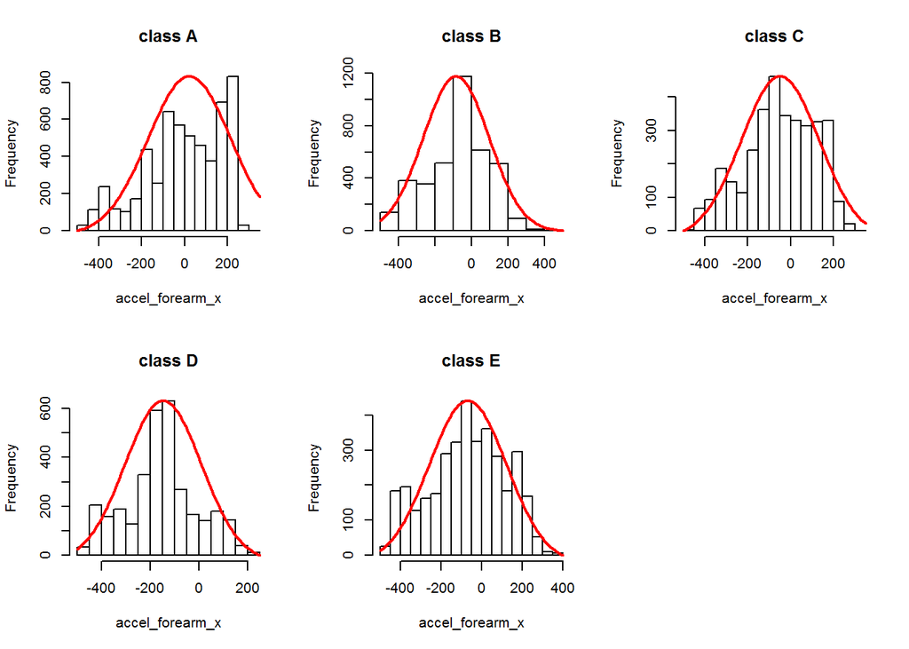

The QDA model assumes the data points of different classes being distributed normally with unknown means and variances, which suit my expectation. I use 10-fold cross-validation for sampling to avoid overfitting.

```r
# train QDA model
tc = trainControl(method = "repeatedcv", number=10, repeats=5)
fitmodel = train(classe ~ ., data = df_train, method='qda',
                 verbose=TRUE,preProcess=c("center","scale"),
                 trControl = tc);
```

Summary of the trained model:

```
## Quadratic Discriminant Analysis
##
## 13737 samples
##    52 predictor
##     5 classes: 'A', 'B', 'C', 'D', 'E'
##
## Pre-processing: centered, scaled
## Resampling: Cross-Validated (10 fold, repeated 5 times)
##
## Summary of sample sizes: 12362, 12364, 12363, 12364, 12365, 12363, ...
##
## Resampling results
##
##   Accuracy  Kappa  Accuracy SD  Kappa SD
##   0.895     0.867  0.00897      0.0113
##
##
```

4. **Estimate Out-of-Sample Error**

Now apply the trained model to the test set and see what the error is.

```r
predvals = predict(fitmodel, df_test)
truevals = df_test$classe
xtab = table(predvals,truevals);
cmat = confusionMatrix(xtab);
cmat
```

```
## Confusion Matrix and Statistics
##
##         truevals
## predvals    A    B    C    D    E
##        A 1553   71    0    2    0
##        B   63  954   65    4   26
##        C   28  105  949  128   40
##        D   27    1    5  809   29
##        E    3    8    7   21  987
##
## Overall Statistics
##
##                Accuracy : 0.8924
##                  95% CI : (0.8842, 0.9002)
##     No Information Rate : 0.2845
##     P-Value [Acc > NIR] : < 2.2e-16
##
##                   Kappa : 0.8641
##  Mcnemar's Test P-Value : < 2.2e-16
##
## Statistics by Class:
##
##                      Class: A Class: B Class: C Class: D Class: E
## Sensitivity            0.9277   0.8376   0.9250   0.8392   0.9122
## Specificity            0.9827   0.9667   0.9381   0.9874   0.9919
## Pos Pred Value         0.9551   0.8579   0.7592   0.9288   0.9620
## Neg Pred Value         0.9716   0.9612   0.9834   0.9691   0.9804
## Prevalence             0.2845   0.1935   0.1743   0.1638   0.1839
## Detection Rate         0.2639   0.1621   0.1613   0.1375   0.1677
## Detection Prevalence   0.2763   0.1890   0.2124   0.1480   0.1743
## Balanced Accuracy      0.9552   0.9021   0.9315   0.9133   0.9520
```

```r
cat("out-of-sample error rate is ",1-cmat$overall[[1]]);
```

```
## out-of-sample error rate is  0.1075616
```

5. **Predict with New Data**

We can now predict the cases in “pml-testing.csv” now, as follows

```r
# predict data in pml-testing.csv
testset = read.csv("pml-testing.csv",na.strings=c(" ","#DIV/0!","NA"));
predvals = predict(fitmodel,testset);
predvals
```

```
##  [1] A A B A A E D B A A B C B A E E A B B B
## Levels: A B C D E
```